# Relatório de Análise de Dados Meteorológicos

2025-05-14

Questão 1 - Qual a cidade é mais quente? Isso muda se considerarmos apenas o período de janeiro e fevereiro (pico do verão)?

Justificativa: A cidade mais quente é João Pessoa e isso não apresenta variação se analisarmos apenas o pico do verão.

Justificativa para a visualização: Para essa questão, foi utilizado um gráfico de barras comparando as médias das temperaturas para o ano inteiro e para os meses de verão. A barra apresenta as médias de temperatura, permitindo uma visualização clara da diferença.

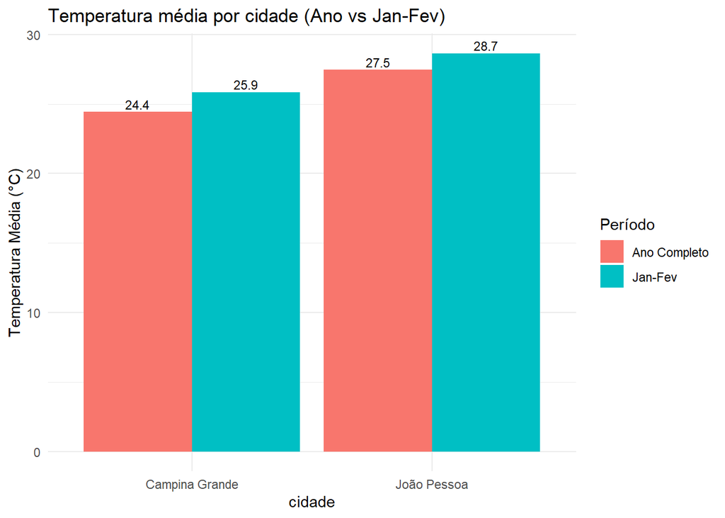

Questão 2 - Quais os meses mais quentes e mais frios? Como você descreveria a temperatura das festas juninas das cidades nos últimos anos?

Justificativa: Os meses mais quentes são dezembro, janeiro, fevereiro e março. A temperatura durante os festejos juninos é bastante amena e com clima extremamente agradável comparando com o restante do ano.

Justificativa para a visualização: Para esta questão, foi escolhido um gráfico de barras que exibe a temperatura média por mês para todas as cidades, permitindo identificar os picos de temperatura.

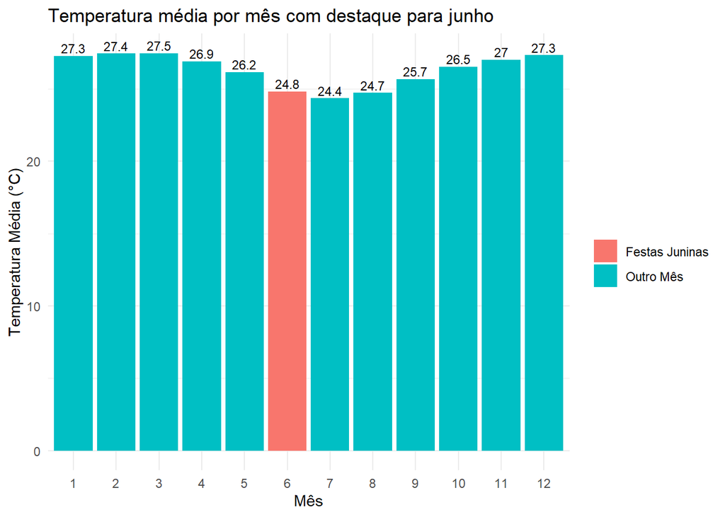

Questão 3 - Quanto chove por semana em JP e CG? Descreva a distribuição do volume de chuvas para as cidades?

Justificativa: Há uma grande variação da chuva por semana em ambas as cidades, mas é extremamente notório que as chuvas em João Pessoa são bem mais frequentes e intensas, registrando um volume bem maior, consequentimente. Portanto a distribuição não é regular e bem variável.

Justificativa para a visualização: Foi utilizado um gráfico de linhas com pontos para cada cidade, mostrando a variação do volume de chuva por semana. Isso permite uma melhor visualização dos dados e fácil comparação entre as cidades.

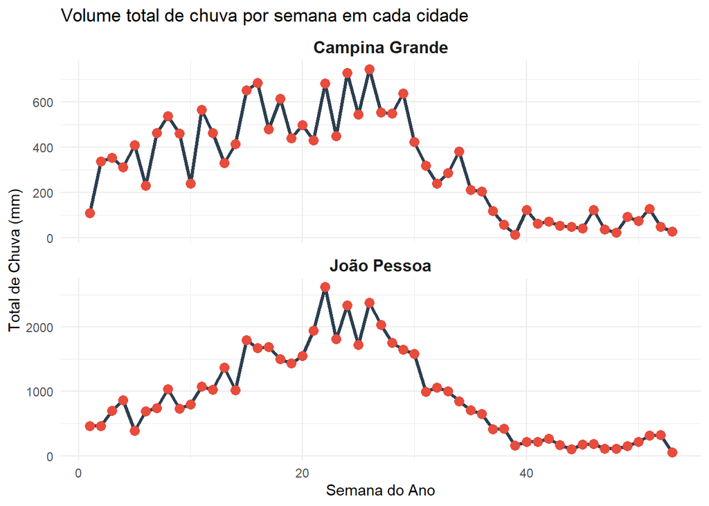

Questão 4 - Qual a relação entre a temperatura de uma semana e a temperatura da semana anterior?

Justificativa para a visualização: Utilizou-se um gráfico de dispersão para observar a relação entre as temperaturas de semanas consecutivas.

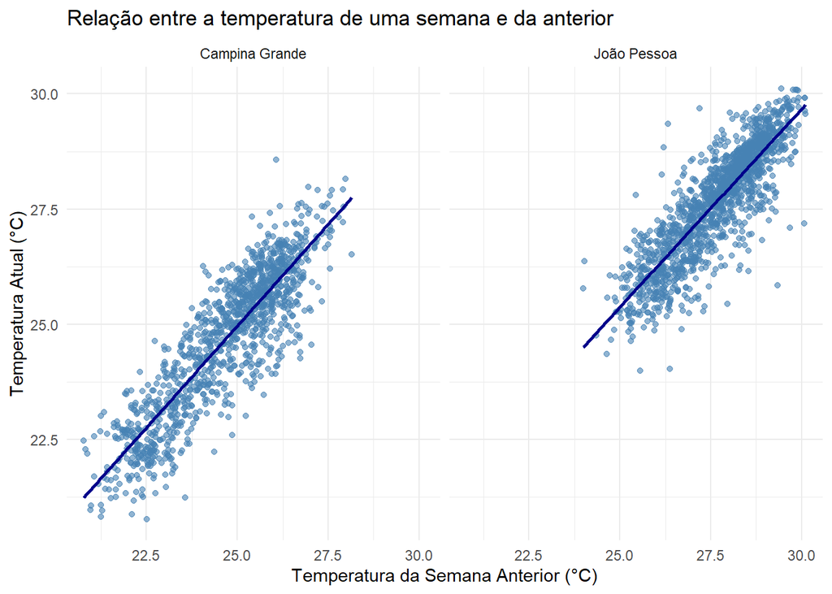

Questão 5 - Qual a relação entre temperatura e chuvas nas semanas em que choveu?

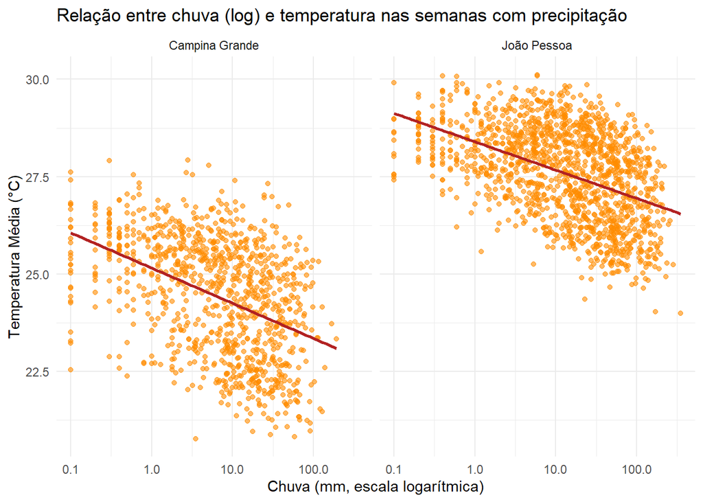